# Final project

Minjie Bao (mb4757), Leo Liu(ll3452), Yutian Luo(yl4608), Cong Zhang(cz2612)

18 December, 2020

# Cong Zhang’s coding part:

## Import Data.

The original dataset `HateCrimes.csv` contains the following 9 variables: state, unemployment, urbanization, median_household_income, perc_population_with_high_school_degree, perc_non_citizen, gini_index, perc_non_white, hate_crimes_per_100k_splc. This dataset has 51 observations and 7 missing values: `hate_crimes_per_100k_splc` values are missing in Hawaii, North Dakota, South Dakota, and Wyoming ; `perc_non_citizen` values are missing in Maine, Mississippi, and South Dakota.

## Explore the distribution of the outcome and consider potential transformations (if the case).

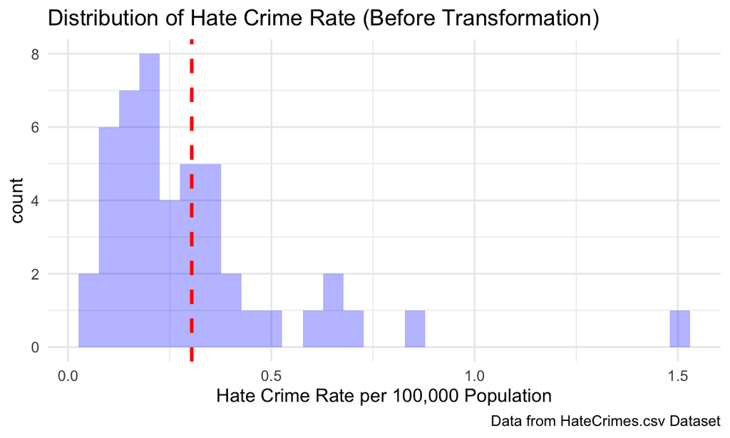

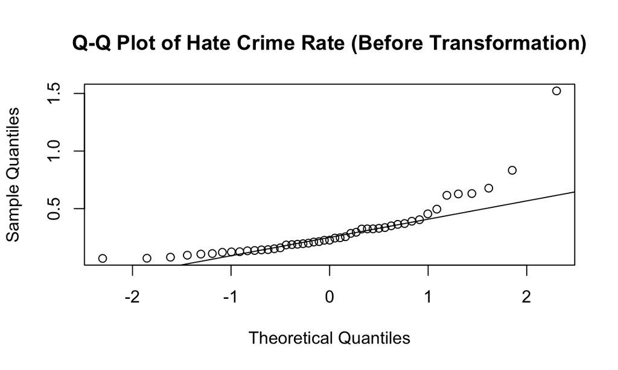

```
   Min. 1st Qu.  Median    Mean 3rd Qu.    Max.    NA's
0.06745 0.14271 0.22620 0.30409 0.35694 1.52230       4
```

From the plots, we could see that the distribution of the hate crime rate of the United States is a positively skewed distribution and there is right tail, which makes the mean higher than the median.

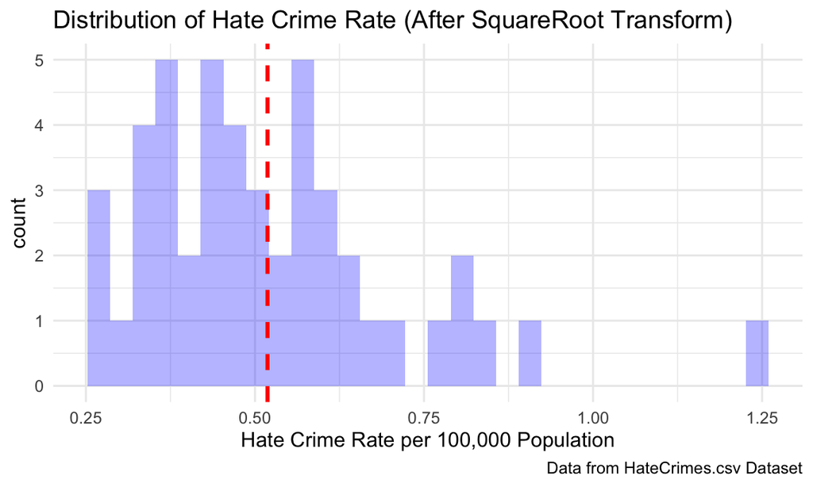

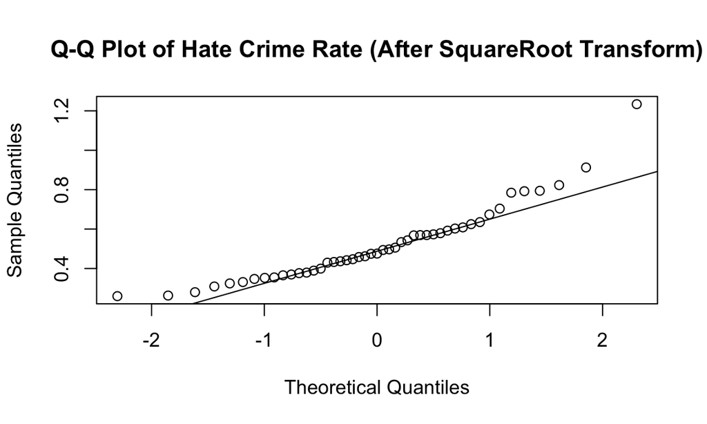

```
   Min. 1st Qu.  Median    Mean 3rd Qu.    Max.    NA's
 0.2597  0.3778  0.4756  0.5186  0.5974  1.2338       4
```

We could see from the graphs that the distribution of square root of hate crime rate of in the United States is still a positively skewed distribution with a right tail.

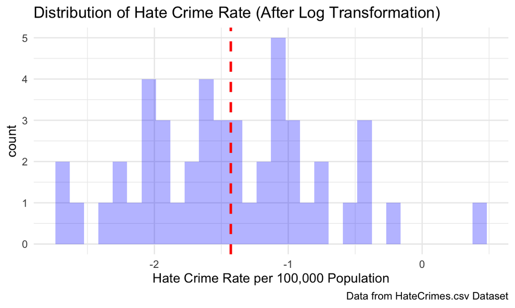

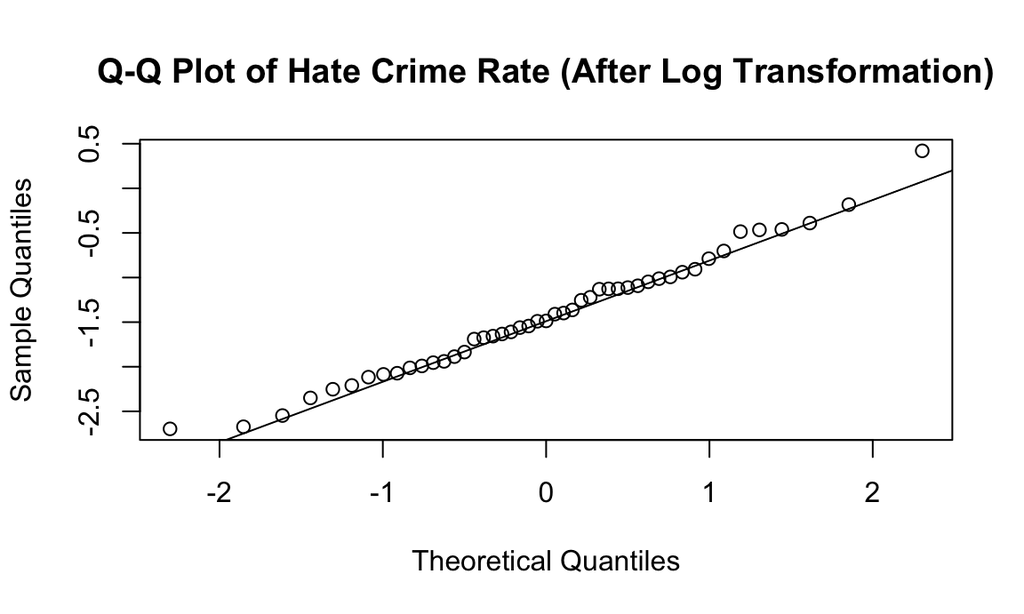

```
   Min. 1st Qu.  Median    Mean 3rd Qu.    Max.    NA's
-2.6964 -1.9470 -1.4863 -1.4290 -1.0304  0.4202       4
```

We could see from the graphs that the distribution of log hate crime rate of in the United States has become relatively normally distributed.

## Identify states with unusual rates and consider them as potential outliers/influential points.

| state | hate_crimes_per_100k_splc |
| --- | --- |
| District of Columbia | 1.52 |
| Oregon | 0.83 |

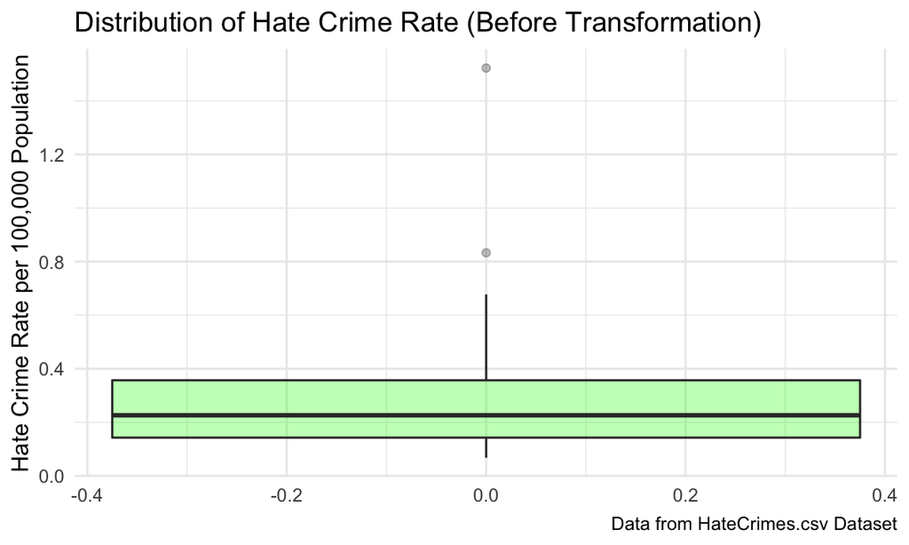

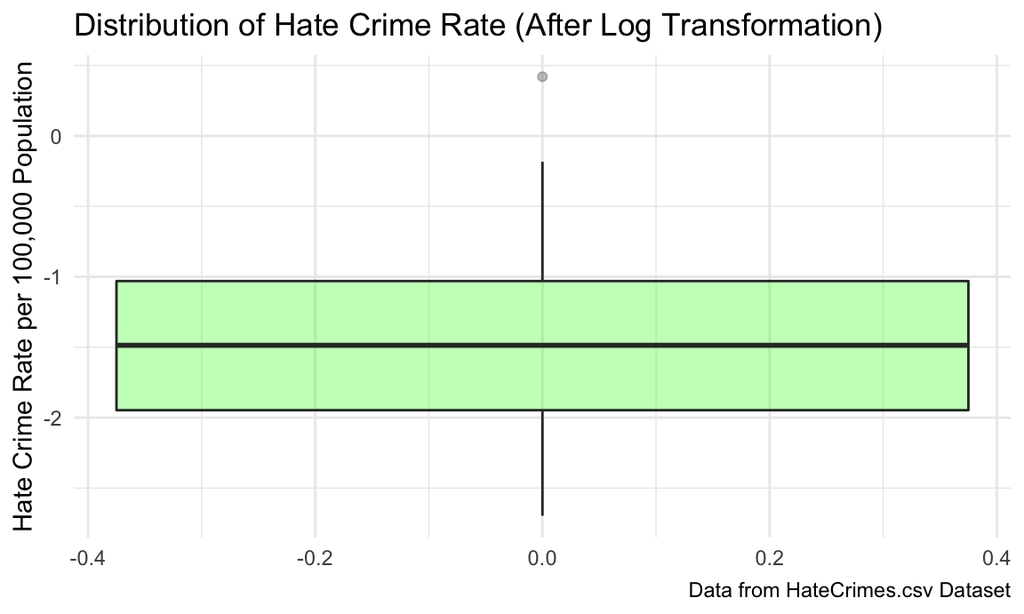

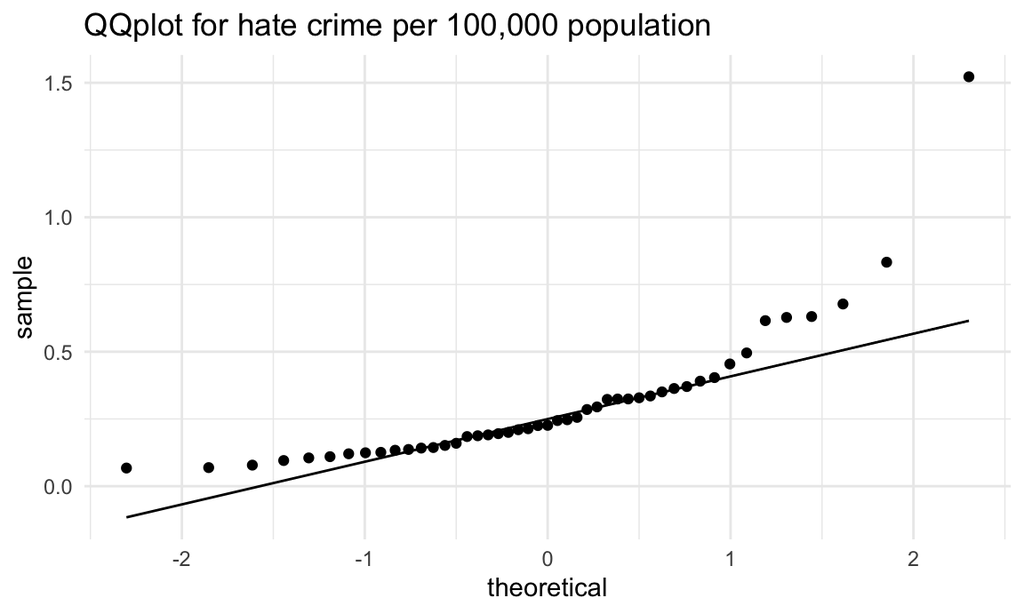

From the graphs, we could also see that before transformation, the hate crime rates of the District of Columbia and Oregon are much higher than the other states, which suggests that these two could be an potential outliers. However, after log transformation, only the hate crime rate of the District of Columbia is still an outlier.

# Minjie Bao’s coding part:

### Consider interactions between variables (e.g., urbanization), and if the case, fit stratified models.

Data summary

| Name | data_crimes |
| --- | --- |
| Number of rows | 51 |
| Number of columns | 9 |
| _______________________ |  |
| Column type frequency: |  |
| character | 1 |
| factor | 2 |
| numeric | 6 |
| ________________________ |  |
| Group variables | None |

**Variable type: character**

| skim_variable | n_missing | complete_rate | min | max | empty | n_unique | whitespace |
| --- | --- | --- | --- | --- | --- | --- | --- |
| state | 0 | 1 | 4 | 20 | 0 | 51 | 0 |

**Variable type: factor**

| skim_variable | n_missing | complete_rate | ordered | n_unique | top_counts |
| --- | --- | --- | --- | --- | --- |
| unemployment | 0 | 1 | FALSE | 2 | 0: 27, 1: 24 |
| urbanization | 0 | 1 | FALSE | 2 | 0: 27, 1: 24 |

**Variable type: numeric**

| skim_variable | n_missing | complete_rate | mean | sd | p0 | p25 | p50 | p75 | p100 | hist |
| --- | --- | --- | --- | --- | --- | --- | --- | --- | --- | --- |
| median_household_income | 0 | 1.00 | 55223.61 | 9208.48 | 35521.00 | 48657.00 | 54916.00 | 60719.00 | 76165.00 | ▂▆▇▅▂ |
| perc_population_with_high_school_degree | 0 | 1.00 | 0.87 | 0.03 | 0.80 | 0.84 | 0.87 | 0.90 | 0.92 | ▃▅▃▆▇ |
| perc_non_citizen | 3 | 0.94 | 0.05 | 0.03 | 0.01 | 0.03 | 0.04 | 0.08 | 0.13 | ▇▆▆▂▂ |
| gini_index | 0 | 1.00 | 0.45 | 0.02 | 0.42 | 0.44 | 0.45 | 0.47 | 0.53 | ▆▇▅▁▁ |
| perc_non_white | 0 | 1.00 | 0.32 | 0.16 | 0.06 | 0.20 | 0.28 | 0.42 | 0.81 | ▇▇▆▂▁ |
| hate_crimes_per_100k_splc | 4 | 0.92 | 0.30 | 0.25 | 0.07 | 0.14 | 0.23 | 0.36 | 1.52 | ▇▂▁▁▁ |

```
Call:
lm(formula = hate_crimes_per_100k_splc ~ unemployment + urbanization +
    median_household_income + perc_population_with_high_school_degree +
    perc_non_citizen + gini_index + perc_non_white, data = data_crimes)

Residuals:
     Min       1Q   Median       3Q      Max
-0.36552 -0.10314 -0.01316  0.09731  0.51389

Coefficients:
                                          Estimate Std. Error t value Pr(>|t|)
(Intercept)                             -8.296e+00  1.908e+00  -4.349 0.000103 ***
unemployment0                            1.307e-02  7.173e-02   0.182 0.856425
urbanization0                            3.309e-02  8.475e-02   0.390 0.698475
median_household_income                 -1.504e-06  5.961e-06  -0.252 0.802193
perc_population_with_high_school_degree  5.382e+00  1.835e+00   2.933 0.005735 **
perc_non_citizen                         1.233e+00  1.877e+00   0.657 0.515332
gini_index                               8.624e+00  1.973e+00   4.370 9.67e-05 ***
perc_non_white                          -5.842e-03  3.673e-01  -0.016 0.987396
---
Signif. codes:  0 '***' 0.001 '**' 0.01 '*' 0.05 '.' 0.1 ' ' 1

Residual standard error: 0.2014 on 37 degrees of freedom
  (6 observations deleted due to missingness)
Multiple R-squared:  0.461, Adjusted R-squared:  0.3591
F-statistic: 4.521 on 7 and 37 DF,  p-value: 0.001007
```

There are two significant variables: perc_population_with_high_school_degree and gini_index.

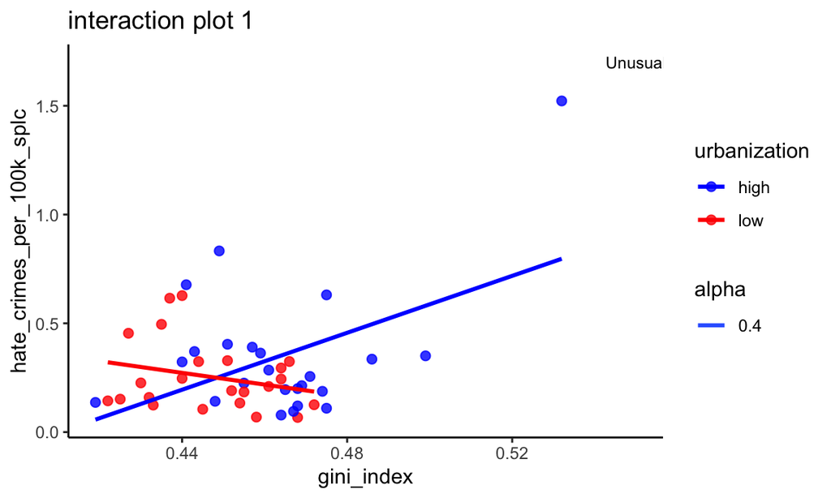

```
Call:
lm(formula = hate_crimes_per_100k_splc ~ gini_index * urbanization,
    data = data_crimes)

Residuals:
     Min       1Q   Median       3Q      Max
-0.31410 -0.16085 -0.04934  0.10459  0.72556

Coefficients:
                         Estimate Std. Error t value Pr(>|t|)
(Intercept)                -2.684      1.019  -2.635  0.01166 *
gini_index                  6.542      2.193   2.984  0.00468 **
urbanization0               4.142      1.779   2.329  0.02464 *
gini_index:urbanization0   -9.238      3.931  -2.350  0.02343 *
---
Signif. codes:  0 '***' 0.001 '**' 0.01 '*' 0.05 '.' 0.1 ' ' 1

Residual standard error: 0.2318 on 43 degrees of freedom
  (4 observations deleted due to missingness)
Multiple R-squared:  0.2134,    Adjusted R-squared:  0.1586
F-statistic: 3.889 on 3 and 43 DF,  p-value: 0.01518
```

```
Call:
lm(formula = hate_crimes_per_100k_splc ~ gini_index, data = high_urban)

Residuals:
    Min      1Q  Median      3Q     Max
-0.3141 -0.1910 -0.0866  0.1302  0.7256

Coefficients:
            Estimate Std. Error t value Pr(>|t|)
(Intercept)   -2.684      1.250  -2.148   0.0430 *
gini_index     6.542      2.690   2.432   0.0236 *
---
Signif. codes:  0 '***' 0.001 '**' 0.01 '*' 0.05 '.' 0.1 ' ' 1

Residual standard error: 0.2844 on 22 degrees of freedom
Multiple R-squared:  0.2119,    Adjusted R-squared:  0.1761
F-statistic: 5.914 on 1 and 22 DF,  p-value: 0.02361
```

```
Call:
lm(formula = hate_crimes_per_100k_splc ~ gini_index, data = low_urban)

Residuals:
     Min       1Q   Median       3Q      Max
-0.17719 -0.13198 -0.04745  0.08652  0.35508

Coefficients:
            Estimate Std. Error t value Pr(>|t|)
(Intercept)    1.459      1.001   1.458    0.160
gini_index    -2.696      2.239  -1.204    0.242

Residual standard error: 0.1591 on 21 degrees of freedom
  (4 observations deleted due to missingness)
Multiple R-squared:  0.06459,   Adjusted R-squared:  0.02004
F-statistic:  1.45 on 1 and 21 DF,  p-value: 0.2419
```

The coefficients change from positive to negative tell us that the effect of gini_index on hate_crimes_per_100k_splc definitely differs by urbanization status!

From the graph, two regression lines for each level category of urbanization interacts with each other. Also, from the model with the interaction term, the p value of the interaction term is 0.02343 < 0.05, so the interaction term is significant.

Since the interaction term is significant, we will do stratification:

For high urbanization, the estimated coefficient of gini_index is 6.542 > 0, which means that with one unit increase in gini_index, the estimated hate_crimes_per_100k_splc level will increase by 6.542 unit. The p value is 0.0236 < 0.05, which means at the significance level of 0.05, the estimated coefficient of gini_index is significantly different than 0.

For low urbanization, the estimated coefficient of gini_index is -2.696 < 0, which means that with one unit increase in gini_index, the estimated hate_crimes_per_100k_splc level will decrease by 2.696 unit. The p value is 0.242 > 0.05, which means at the significance level of 0.05, the estimated coefficient of gini_index is not significantly different than 0.

As we can see, the slopes of high and low urbanization have different directionality, which means the associations between gini_index and hate_crimes_per_100k_splc level have opposite directions for the two groups.

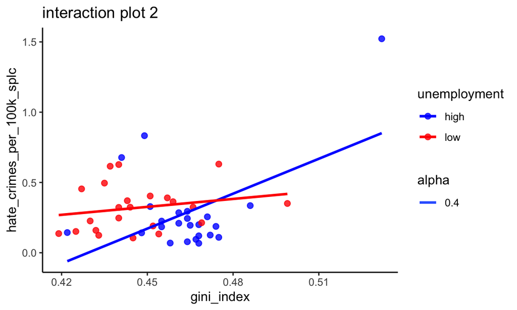

```
Call:
lm(formula = hate_crimes_per_100k_splc ~ gini_index * unemployment,
    data = data_crimes)

Residuals:
     Min       1Q   Median       3Q      Max
-0.26910 -0.14406 -0.05300  0.05402  0.67146

Coefficients:
                         Estimate Std. Error t value Pr(>|t|)
(Intercept)                -3.555      1.156  -3.075  0.00365 **
gini_index                  8.281      2.489   3.327  0.00180 **
unemployment0               3.035      1.665   1.823  0.07534 .
gini_index:unemployment0   -6.400      3.658  -1.750  0.08733 .
---
Signif. codes:  0 '***' 0.001 '**' 0.01 '*' 0.05 '.' 0.1 ' ' 1

Residual standard error: 0.2316 on 43 degrees of freedom
  (4 observations deleted due to missingness)
Multiple R-squared:  0.215, Adjusted R-squared:  0.1603
F-statistic: 3.926 on 3 and 43 DF,  p-value: 0.01457
```

Although the visualization above indicates that an interaction might exist, from the numeric summaries, the p-value of gini_index:unemployment0 is not significant(p-value = 0.08733 > 0.05). Therefore, there’s no evidence of interaction of gini_index and unemployment, which means the effect of gini_index on hate_crimes_per_100k_splc is not different with respect to the levels of unemployment.

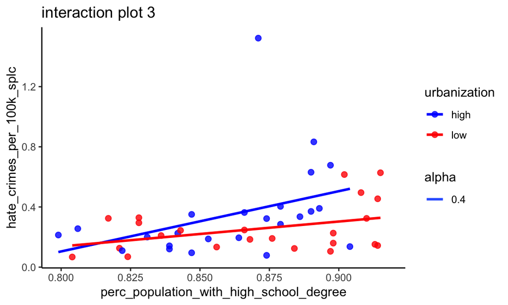

```
Call:
lm(formula = hate_crimes_per_100k_splc ~ perc_population_with_high_school_degree *
    urbanization, data = data_crimes)

Residuals:
     Min       1Q   Median       3Q      Max
-0.38440 -0.12402 -0.06568  0.11205  1.13354

Coefficients:
                                                      Estimate Std. Error t value Pr(>|t|)
(Intercept)                                             -3.100      1.464  -2.117   0.0401 *
perc_population_with_high_school_degree                  4.006      1.698   2.359   0.0229 *
urbanization0                                            1.913      1.870   1.023   0.3120
perc_population_with_high_school_degree:urbanization0   -2.350      2.160  -1.088   0.2828
---
Signif. codes:  0 '***' 0.001 '**' 0.01 '*' 0.05 '.' 0.1 ' ' 1

Residual standard error: 0.2375 on 43 degrees of freedom
  (4 observations deleted due to missingness)
Multiple R-squared:  0.1745,    Adjusted R-squared:  0.1169
F-statistic:  3.03 on 3 and 43 DF,  p-value: 0.03951
```

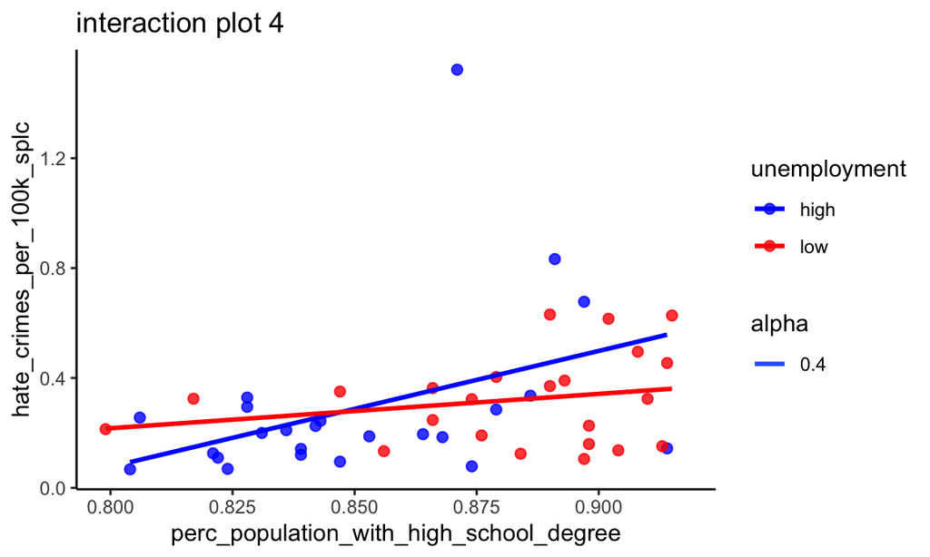

```
Call:
lm(formula = hate_crimes_per_100k_splc ~ perc_population_with_high_school_degree *
    unemployment, data = data_crimes)

Residuals:
     Min       1Q   Median       3Q      Max
-0.41372 -0.12303 -0.02848  0.08708  1.14619

Coefficients:
                                                      Estimate Std. Error t value Pr(>|t|)
(Intercept)                                             -3.297      1.466  -2.250   0.0296 *
perc_population_with_high_school_degree                  4.217      1.723   2.448   0.0185 *
unemployment0                                            2.514      2.109   1.192   0.2398
perc_population_with_high_school_degree:unemployment0   -2.967      2.432  -1.220   0.2292
---
Signif. codes:  0 '***' 0.001 '**' 0.01 '*' 0.05 '.' 0.1 ' ' 1

Residual standard error: 0.2431 on 43 degrees of freedom
  (4 observations deleted due to missingness)
Multiple R-squared:  0.1351,    Adjusted R-squared:  0.07479
F-statistic:  2.24 on 3 and 43 DF,  p-value: 0.0973
```

Although the visualization above indicates that an interaction might exist; however, from the numeric summaries, the p-value of perc_population_with_high_school_degree:unemployment0 is 0.2292 > 0.05 which is not significant. Therefore, there’s no evidence of interaction of perc_population_with_high_school_degree and unemployment, which means the effect of perc_population_with_high_school_degree on hate_crimes_per_100k_splc is not different with respect to the levels of unemployment.

Counfounder:

Condition 1)

```
Call:
lm(formula = hate_crimes_per_100k_splc ~ urbanization, data = data_crimes)

Residuals:
     Min       1Q   Median       3Q      Max
-0.27357 -0.14369 -0.06352  0.04624  1.17043

Coefficients:
              Estimate Std. Error t value Pr(>|t|)
(Intercept)    0.35187    0.05115   6.879 1.54e-08 ***
urbanization0 -0.09763    0.07312  -1.335    0.189
---
Signif. codes:  0 '***' 0.001 '**' 0.01 '*' 0.05 '.' 0.1 ' ' 1

Residual standard error: 0.2506 on 45 degrees of freedom
  (4 observations deleted due to missingness)
Multiple R-squared:  0.03811,   Adjusted R-squared:  0.01673
F-statistic: 1.783 on 1 and 45 DF,  p-value: 0.1885
```

```
Analysis of Variance Table

Response: hate_crimes_per_100k_splc
             Df  Sum Sq  Mean Sq F value Pr(>F)
urbanization  1 0.11195 0.111953  1.7829 0.1885
Residuals    45 2.82568 0.062793
```

urbanization not associated with the outcome

Condition 2)

```
Call:
lm(formula = gini_index ~ urbanization, data = data_crimes)

Residuals:
      Min        1Q    Median        3Q       Max
-0.045000 -0.012167 -0.000667  0.010167  0.068000

Coefficients:
               Estimate Std. Error t value Pr(>|t|)
(Intercept)    0.464000   0.003810 121.781  < 2e-16 ***
urbanization0 -0.019333   0.005237  -3.692 0.000559 ***
---
Signif. codes:  0 '***' 0.001 '**' 0.01 '*' 0.05 '.' 0.1 ' ' 1

Residual standard error: 0.01867 on 49 degrees of freedom
Multiple R-squared:  0.2176,    Adjusted R-squared:  0.2017
F-statistic: 13.63 on 1 and 49 DF,  p-value: 0.0005592
```

```
Analysis of Variance Table

Response: gini_index
             Df    Sum Sq   Mean Sq F value    Pr(>F)
urbanization  1 0.0047492 0.0047492  13.631 0.0005592 ***
Residuals    49 0.0170720 0.0003484
---
Signif. codes:  0 '***' 0.001 '**' 0.01 '*' 0.05 '.' 0.1 ' ' 1
```

urbanization associated with the exposure

```
Call:
lm(formula = hate_crimes_per_100k_splc ~ gini_index, data = data_crimes)

Residuals:
     Min       1Q   Median       3Q      Max
-0.28669 -0.14565 -0.04991  0.07356  0.91085

Coefficients:
            Estimate Std. Error t value Pr(>|t|)
(Intercept)  -1.5275     0.7833  -1.950   0.0574 .
gini_index    4.0205     1.7177   2.341   0.0237 *
---
Signif. codes:  0 '***' 0.001 '**' 0.01 '*' 0.05 '.' 0.1 ' ' 1

Residual standard error: 0.2412 on 45 degrees of freedom
  (4 observations deleted due to missingness)
Multiple R-squared:  0.1085,    Adjusted R-squared:  0.08872
F-statistic: 5.478 on 1 and 45 DF,  p-value: 0.02374
```

```
Call:
lm(formula = hate_crimes_per_100k_splc ~ gini_index + urbanization,
    data = data_crimes)

Residuals:
     Min       1Q   Median       3Q      Max
-0.28248 -0.14938 -0.05577  0.06162  0.92103

Coefficients:
              Estimate Std. Error t value Pr(>|t|)
(Intercept)   -1.34994    0.88817  -1.520   0.1357
gini_index     3.66771    1.91115   1.919   0.0615 .
urbanization0 -0.03433    0.07832  -0.438   0.6633
---
Signif. codes:  0 '***' 0.001 '**' 0.01 '*' 0.05 '.' 0.1 ' ' 1

Residual standard error: 0.2434 on 44 degrees of freedom
  (4 observations deleted due to missingness)
Multiple R-squared:  0.1124,    Adjusted R-squared:  0.07206
F-statistic: 2.786 on 2 and 44 DF,  p-value: 0.07256
```

```
Analysis of Variance Table

Response: hate_crimes_per_100k_splc
             Df  Sum Sq Mean Sq F value  Pr(>F)
gini_index    1 0.31882 0.31882  5.3801 0.02507 *
urbanization  1 0.01138 0.01138  0.1921 0.66333
Residuals    44 2.60743 0.05926
---
Signif. codes:  0 '***' 0.001 '**' 0.01 '*' 0.05 '.' 0.1 ' ' 1
```

for gini_index be on the causal path way it means gini_index impacts urbanization, urbanization impact hate_crimes_per_100k_splc, in this case gini_index not on the path way.

By adjusting to urbanization the coefficient of gini_index reduced by almost 9%. Therefore, urbanization does not confoud the relationship between gini_index and hate_crimes_per_100k_splc.

The gini_index coefficient reduced from 4.0205 in SLR to 3.66771 in MLR after adjusting for urbanization (~9% reduction).

We can conclude that urbanization not confounds the relationship b/w gini_index and hate_crimes_per_100k_splc.

# Yutian Luo’s coding part:

## Verify if this association holds true in this dataset, but also explore associations of all the other covariates mentioned above and draw your own conclusions.

```
    the initial analysis published by FiveThirtyEight showed that income inequality was the main predictor of hate crimes rates.
```

## why use gini index to represent inequality

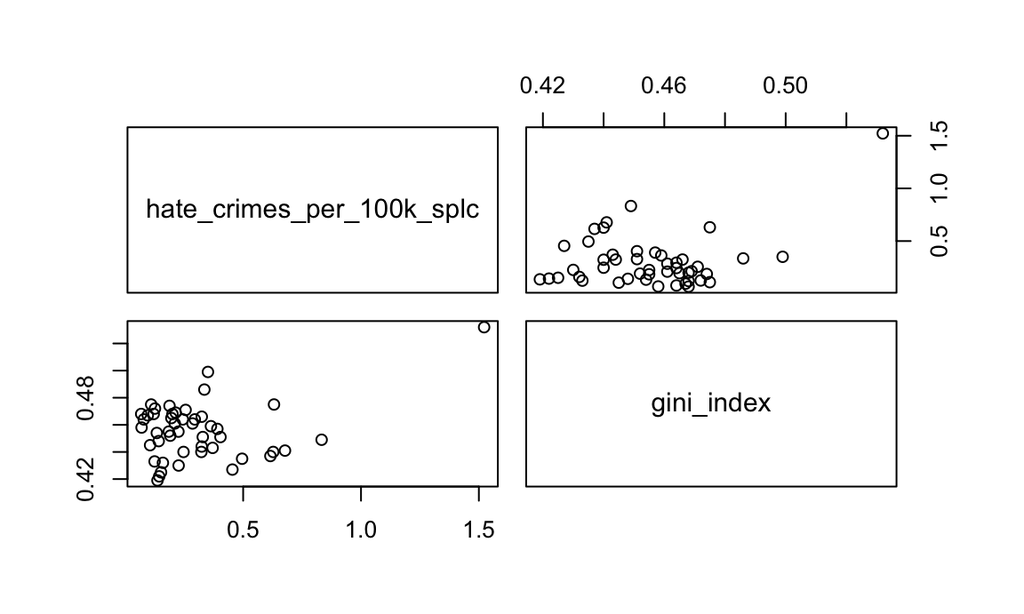

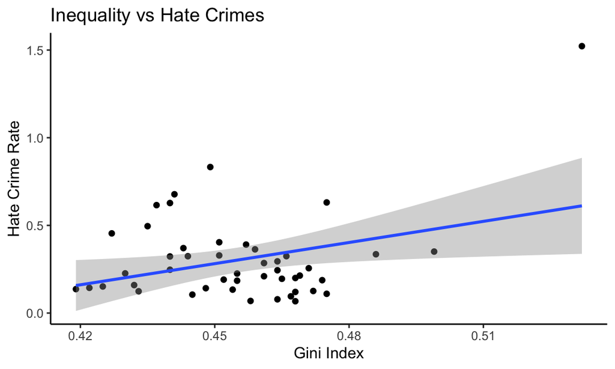

From our initial association analysis, there is limited association between the two variables.

We furthere analyze by linear method.

```
Call:
lm(formula = hate_crimes_per_100k_splc ~ gini_index, data = hatecrime_df)

Residuals:
     Min       1Q   Median       3Q      Max
-0.28669 -0.14565 -0.04991  0.07356  0.91085

Coefficients:
            Estimate Std. Error t value Pr(>|t|)
(Intercept)  -1.5275     0.7833  -1.950   0.0574 .
gini_index    4.0205     1.7177   2.341   0.0237 *
---
Signif. codes:  0 '***' 0.001 '**' 0.01 '*' 0.05 '.' 0.1 ' ' 1

Residual standard error: 0.2412 on 45 degrees of freedom
  (4 observations deleted due to missingness)
Multiple R-squared:  0.1085,    Adjusted R-squared:  0.08872
F-statistic: 5.478 on 1 and 45 DF,  p-value: 0.02374
```

```
Analysis of Variance Table

Response: hate_crimes_per_100k_splc
           Df  Sum Sq Mean Sq F value  Pr(>F)
gini_index  1 0.31882 0.31882  5.4784 0.02374 *
Residuals  45 2.61881 0.05820
---
Signif. codes:  0 '***' 0.001 '**' 0.01 '*' 0.05 '.' 0.1 ' ' 1
```

From the t test, we conclude that we are 95% confident that the inequality has a positive linear association with the hate crime rate.

This suggests that the higher inequality is, the higher rate of hate crime will occur.

## futher interpreate

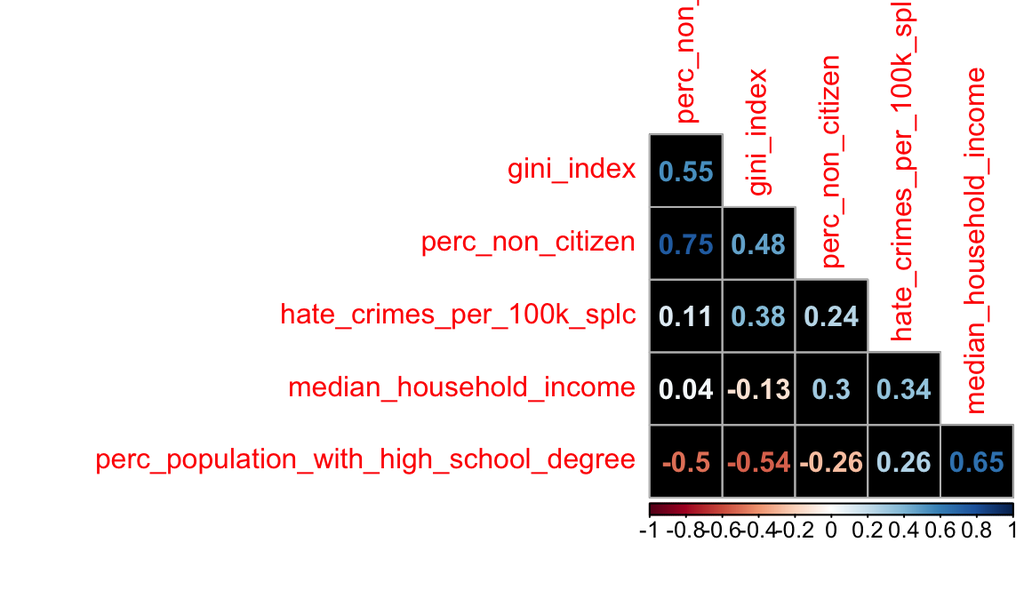

The other pair of moderate correlation is between inequality and population’s high school degreee percentage; inequality with percent of alien; education with percent of none white; and education with inequality.

## mlr model

Our hypothesis for mlr model: 1. gini index 2. education

We use correlation matrix to propose for a mlr model in part 4 Exploration

# Leo Liu’s coding part:

```
Call:
lm(formula = hate_crimes_per_100k_splc ~ unemployment + urbanization +
    median_household_income + perc_population_with_high_school_degree +
    perc_non_citizen + gini_index + perc_non_white + gini_index *
    urbanization, data = hc_df)

Residuals:
     Min       1Q   Median       3Q      Max
-0.37526 -0.09740 -0.03516  0.09331  0.52712

Coefficients:
                                          Estimate Std. Error t value Pr(>|t|)
(Intercept)                             -8.412e+00  1.946e+00  -4.322 0.000117 ***
unemploymentlow                          1.432e-02  7.258e-02   0.197 0.844673
urbanizationlow                         -8.459e-01  1.978e+00  -0.428 0.671479
median_household_income                 -1.318e-06  6.041e-06  -0.218 0.828546
perc_population_with_high_school_degree  5.661e+00  1.958e+00   2.890 0.006482 **
perc_non_citizen                         1.397e+00  1.933e+00   0.723 0.474501
gini_index                               8.311e+00  2.115e+00   3.929 0.000370 ***
perc_non_white                          -1.344e-02  3.718e-01  -0.036 0.971353
urbanizationlow:gini_index               1.965e+00  4.419e+00   0.445 0.659157
---
Signif. codes:  0 '***' 0.001 '**' 0.01 '*' 0.05 '.' 0.1 ' ' 1

Residual standard error: 0.2036 on 36 degrees of freedom
Multiple R-squared:  0.464, Adjusted R-squared:  0.3448
F-statistic: 3.895 on 8 and 36 DF,  p-value: 0.002136
```

```
                        unemploymentlow                         urbanizationlow                 median_household_income
                               1.428645                             1057.044019                                3.123157
perc_population_with_high_school_degree                        perc_non_citizen                              gini_index
                               4.341070                                3.869728                                2.074331
                         perc_non_white              urbanizationlow:gini_index
                               3.243274                             1052.161495
```

```
                                        median_household_income perc_population_with_high_school_degree perc_non_citizen gini_index perc_non_white
median_household_income                              1.00000000                               0.6511383        0.3017394 -0.1295216     0.03905399
perc_population_with_high_school_degree              0.65113832                               1.0000000       -0.2621288 -0.5371591    -0.49589321
perc_non_citizen                                     0.30173941                              -0.2621288        1.0000000  0.4798976     0.75261020
gini_index                                          -0.12952158                              -0.5371591        0.4798976  1.0000000     0.54840351
perc_non_white                                       0.03905399                              -0.4958932        0.7526102  0.5484035     1.00000000
hate_crimes_per_100k_splc                            0.34378921                               0.2628198        0.2435066  0.3805028     0.11116503
                                        hate_crimes_per_100k_splc
median_household_income                                 0.3437892
perc_population_with_high_school_degree                 0.2628198
perc_non_citizen                                        0.2435066
gini_index                                              0.3805028
perc_non_white                                          0.1111650
hate_crimes_per_100k_splc                               1.0000000
```

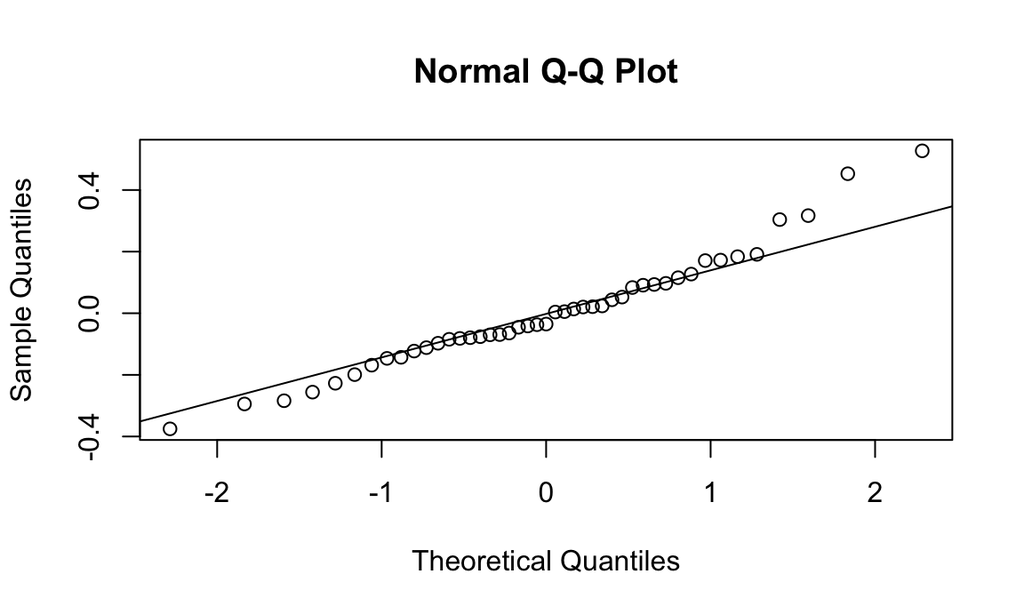

```
Start:  AIC=-135.28
hate_crimes_per_100k_splc ~ unemployment + urbanization + median_household_income +
    perc_population_with_high_school_degree + perc_non_citizen +
    gini_index + perc_non_white + gini_index * urbanization

                                          Df Sum of Sq    RSS     AIC
- perc_non_white                           1   0.00005 1.4926 -137.28
- unemployment                             1   0.00161 1.4942 -137.23
- median_household_income                  1   0.00197 1.4946 -137.22
- urbanization:gini_index                  1   0.00820 1.5008 -137.03
- perc_non_citizen                         1   0.02166 1.5142 -136.63
<none>                                                 1.4926 -135.28
- perc_population_with_high_school_degree  1   0.34638 1.8390 -127.89

Step:  AIC=-137.28
hate_crimes_per_100k_splc ~ unemployment + urbanization + median_household_income +
    perc_population_with_high_school_degree + perc_non_citizen +
    gini_index + urbanization:gini_index

                                          Df Sum of Sq    RSS     AIC
- unemployment                             1   0.00186 1.4945 -139.22
- median_household_income                  1   0.00212 1.4948 -139.21
- urbanization:gini_index                  1   0.00816 1.5008 -139.03
- perc_non_citizen                         1   0.02904 1.5217 -138.41
<none>                                                 1.4926 -137.28
- perc_population_with_high_school_degree  1   0.37841 1.8710 -129.11

Step:  AIC=-139.22
hate_crimes_per_100k_splc ~ urbanization + median_household_income +
    perc_population_with_high_school_degree + perc_non_citizen +
    gini_index + urbanization:gini_index

                                          Df Sum of Sq    RSS     AIC
- median_household_income                  1   0.00187 1.4964 -141.16
- urbanization:gini_index                  1   0.00779 1.5023 -140.99
- perc_non_citizen                         1   0.02866 1.5232 -140.37
<none>                                                 1.4945 -139.22
- perc_population_with_high_school_degree  1   0.39187 1.8863 -130.74

Step:  AIC=-141.16
```

[output cut: 23 more lines]

```

                                          Df Sum of Sq    RSS     AIC
- perc_non_citizen                         1   0.01471 1.5270 -146.25
<none>                                                 1.5123 -144.69
- gini_index                               1   0.78804 2.3004 -127.81
- perc_population_with_high_school_degree  1   0.85561 2.3679 -126.51

Step:  AIC=-146.25
hate_crimes_per_100k_splc ~ perc_population_with_high_school_degree +
    gini_index

                                          Df Sum of Sq    RSS     AIC
<none>                                                 1.5270 -146.25
- perc_population_with_high_school_degree  1   0.85432 2.3813 -128.25
- gini_index                               1   1.06513 2.5922 -124.44
```

```
Call:
lm(formula = hate_crimes_per_100k_splc ~ perc_population_with_high_school_degree +
    gini_index, data = hc_df)

Coefficients:
                            (Intercept)  perc_population_with_high_school_degree                               gini_index
                                 -8.103                                    5.059                                    8.825
```

```
Start:  AIC=-135.28
hate_crimes_per_100k_splc ~ unemployment + urbanization + median_household_income +
    perc_population_with_high_school_degree + perc_non_citizen +
    gini_index + perc_non_white + gini_index * urbanization

                                          Df Sum of Sq    RSS     AIC
- perc_non_white                           1   0.00005 1.4926 -137.28
- unemployment                             1   0.00161 1.4942 -137.23
- median_household_income                  1   0.00197 1.4946 -137.22
- urbanization:gini_index                  1   0.00820 1.5008 -137.03
- perc_non_citizen                         1   0.02166 1.5142 -136.63
<none>                                                 1.4926 -135.28
- perc_population_with_high_school_degree  1   0.34638 1.8390 -127.89

Step:  AIC=-137.28
hate_crimes_per_100k_splc ~ unemployment + urbanization + median_household_income +
    perc_population_with_high_school_degree + perc_non_citizen +
    gini_index + urbanization:gini_index

                                          Df Sum of Sq    RSS     AIC
- unemployment                             1   0.00186 1.4945 -139.22
- median_household_income                  1   0.00212 1.4948 -139.21
- urbanization:gini_index                  1   0.00816 1.5008 -139.03
- perc_non_citizen                         1   0.02904 1.5217 -138.41
<none>                                                 1.4926 -137.28
+ perc_non_white                           1   0.00005 1.4926 -135.28
- perc_population_with_high_school_degree  1   0.37841 1.8710 -129.11

Step:  AIC=-139.22
hate_crimes_per_100k_splc ~ urbanization + median_household_income +
    perc_population_with_high_school_degree + perc_non_citizen +
    gini_index + urbanization:gini_index

                                          Df Sum of Sq    RSS     AIC
- median_household_income                  1   0.00187 1.4964 -141.16
- urbanization:gini_index                  1   0.00779 1.5023 -140.99
- perc_non_citizen                         1   0.02866 1.5232 -140.37
<none>                                                 1.4945 -139.22
+ unemployment                             1   0.00186 1.4926 -137.28
+ perc_non_white                           1   0.00030 1.4942 -137.23
```

[output cut: 42 more lines]

```
- perc_population_with_high_school_degree  1   0.85561 2.3679 -126.51

Step:  AIC=-146.25
hate_crimes_per_100k_splc ~ perc_population_with_high_school_degree +
    gini_index

                                          Df Sum of Sq    RSS     AIC
<none>                                                 1.5270 -146.25
+ perc_non_citizen                         1   0.01471 1.5123 -144.69
+ perc_non_white                           1   0.00522 1.5218 -144.40
+ unemployment                             1   0.00136 1.5257 -144.29
+ median_household_income                  1   0.00068 1.5263 -144.27
+ urbanization                             1   0.00001 1.5270 -144.25
- perc_population_with_high_school_degree  1   0.85432 2.3813 -128.25
- gini_index                               1   1.06513 2.5922 -124.44
```

```
Call:
lm(formula = hate_crimes_per_100k_splc ~ perc_population_with_high_school_degree +
    gini_index, data = hc_df)

Coefficients:
                            (Intercept)  perc_population_with_high_school_degree                               gini_index
                                 -8.103                                    5.059                                    8.825
```

```
Call:
lm(formula = hate_crimes_per_100k_splc ~ perc_population_with_high_school_degree +
    gini_index, data = hc_df)

Residuals:
     Min       1Q   Median       3Q      Max
-0.33490 -0.11891 -0.03105  0.11430  0.52418

Coefficients:
                                        Estimate Std. Error t value Pr(>|t|)
(Intercept)                               -8.103      1.447  -5.601 1.48e-06 ***
perc_population_with_high_school_degree    5.059      1.044   4.847 1.74e-05 ***
gini_index                                 8.825      1.630   5.413 2.76e-06 ***
---
Signif. codes:  0 '***' 0.001 '**' 0.01 '*' 0.05 '.' 0.1 ' ' 1

Residual standard error: 0.1907 on 42 degrees of freedom
Multiple R-squared:  0.4516,    Adjusted R-squared:  0.4255
F-statistic: 17.29 on 2 and 42 DF,  p-value: 3.32e-06
```

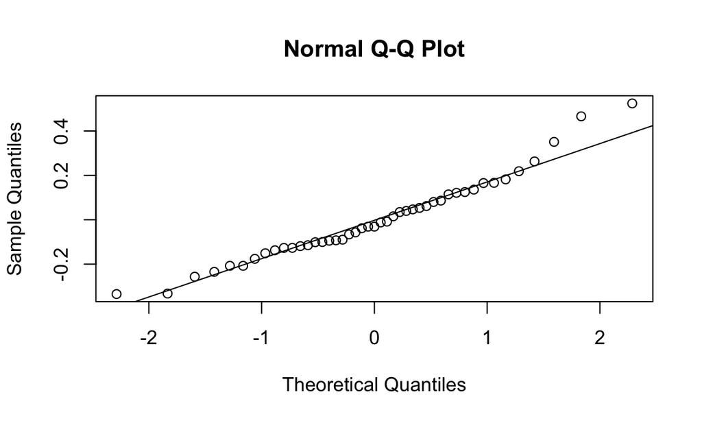

```
perc_population_with_high_school_degree                              gini_index
                                1.40556                                 1.40556
```

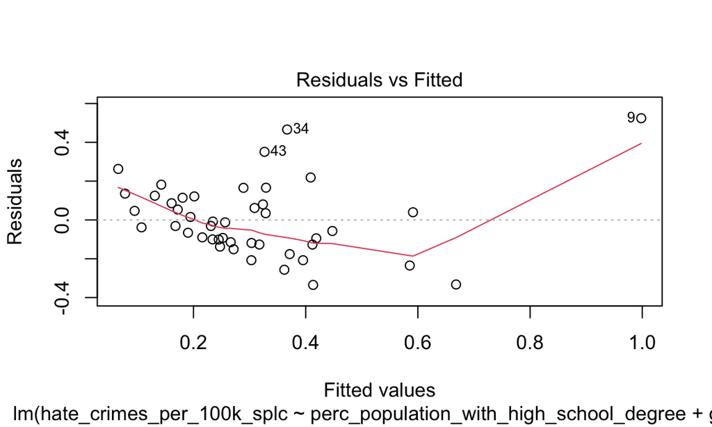

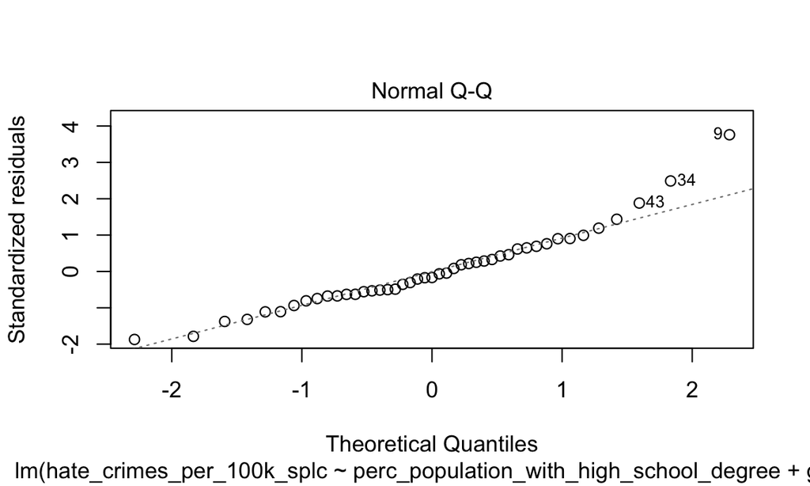

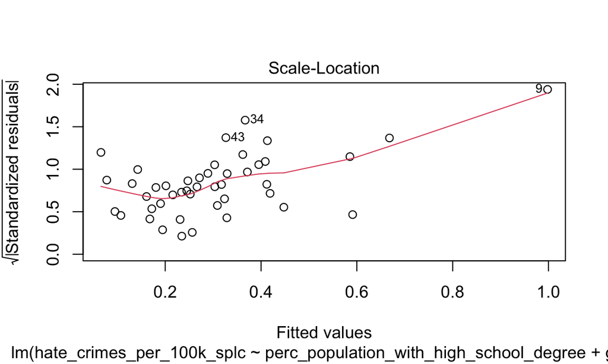

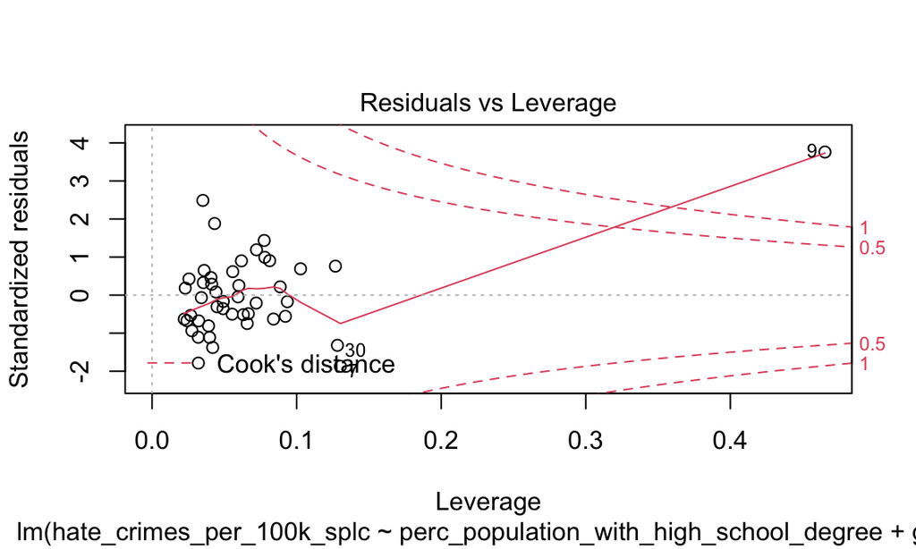

## Exclude outliers

```
# A tibble: 1 x 9
  state        unemployment urbanization median_household_i… perc_population_with_high… perc_non_citizen gini_index perc_non_white hate_crimes_per_10…
  <chr>        <fct>        <fct>                      <dbl>                      <dbl>            <dbl>      <dbl>          <dbl>               <dbl>
1 District of… high         high                       68277                      0.871             0.11      0.532           0.63                1.52
```

```
Call:
lm(formula = hate_crimes_per_100k_splc ~ perc_population_with_high_school_degree +
    gini_index, data = hc_df_no_outliers)

Residuals:
     Min       1Q   Median       3Q      Max
-0.25186 -0.10799 -0.02101  0.09700  0.49954

Coefficients:
                                        Estimate Std. Error t value Pr(>|t|)
(Intercept)                              -3.8396     1.5151  -2.534  0.01519 *
perc_population_with_high_school_degree   3.0482     0.9666   3.154  0.00302 **
gini_index                                3.2449     1.8174   1.785  0.08159 .
---
Signif. codes:  0 '***' 0.001 '**' 0.01 '*' 0.05 '.' 0.1 ' ' 1

Residual standard error: 0.1572 on 41 degrees of freedom
Multiple R-squared:  0.1977,    Adjusted R-squared:  0.1585
F-statistic: 5.051 on 2 and 41 DF,  p-value: 0.01094
```

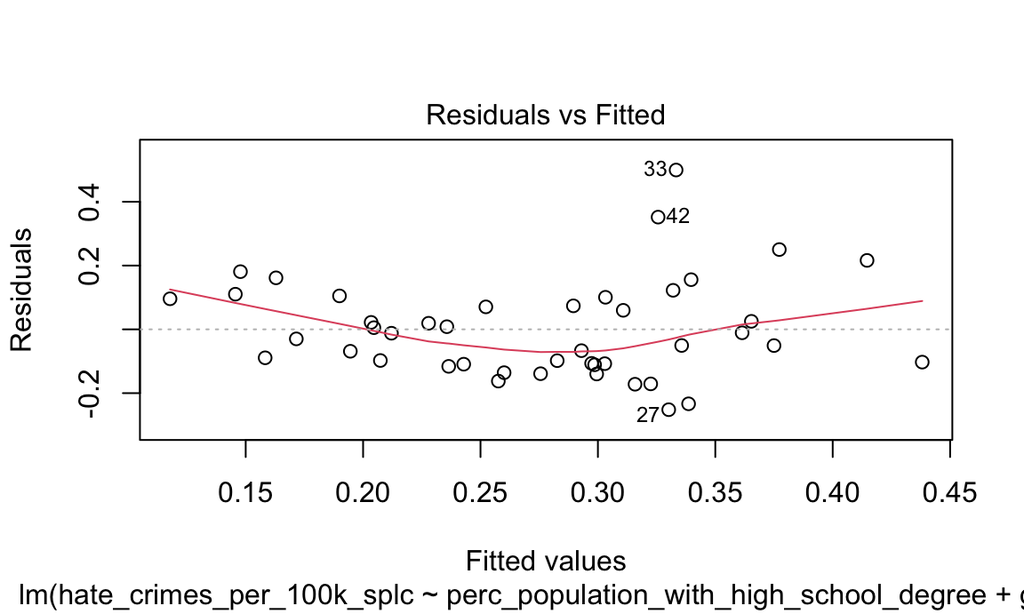

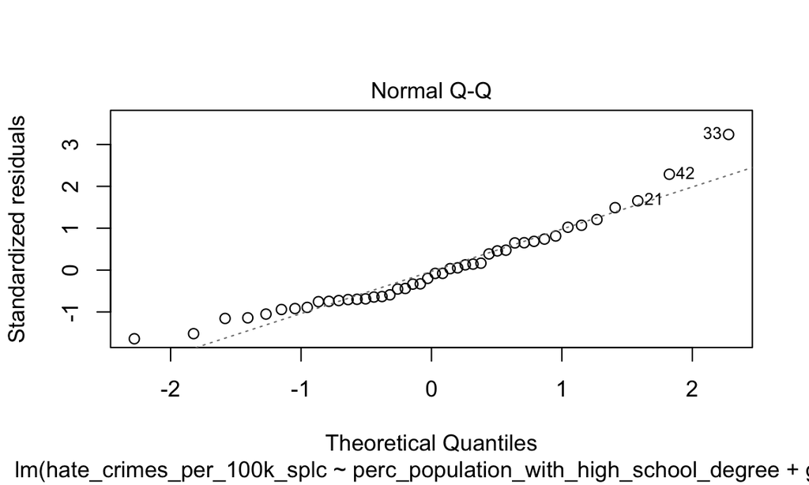

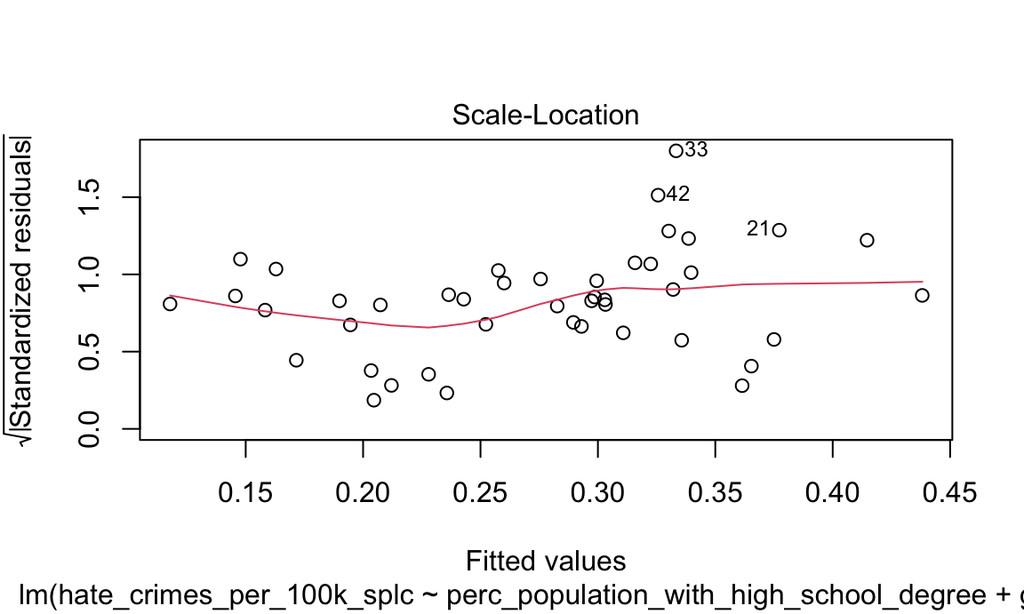

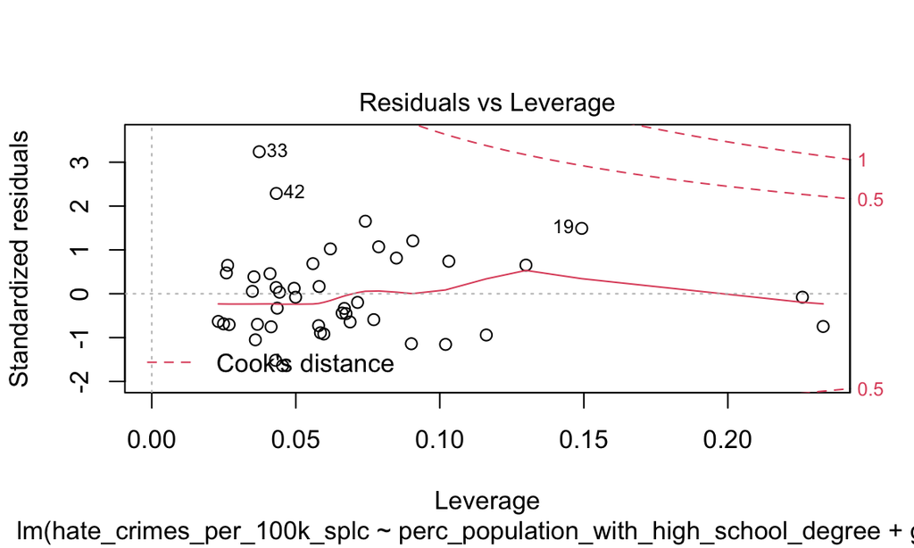

```
                                           2.5 %  97.5 %
perc_population_with_high_school_degree 1.096097 5.00024
```

```
                2.5 %   97.5 %
gini_index -0.4255136 6.915284
```

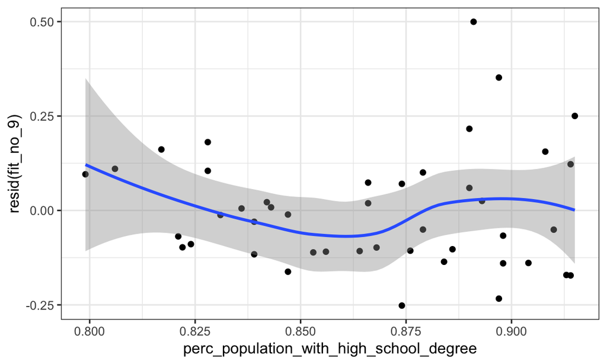

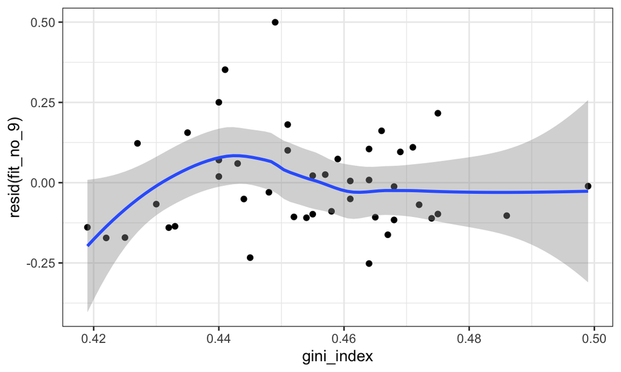

# Deal with collinearity

```
perc_population_with_high_school_degree                              gini_index
                               1.773775                                1.773775
```

No multicollinearity issues.

```
Call:
lm(formula = hate_crimes_per_100k_splc ~ perc_population_with_high_school_degree +
    gini_index * urbanization + gini_index, data = hc_df)

Residuals:
     Min       1Q   Median       3Q      Max
-0.33743 -0.12559 -0.02552  0.10649  0.53288

Coefficients:
                                        Estimate Std. Error t value Pr(>|t|)
(Intercept)                              -8.1782     1.5853  -5.159 7.13e-06 ***
perc_population_with_high_school_degree   5.2314     1.2693   4.121 0.000184 ***
gini_index                                8.6674     1.9173   4.521 5.38e-05 ***
urbanizationlow                          -0.4743     1.8377  -0.258 0.797673
gini_index:urbanizationlow                1.0506     4.0781   0.258 0.798014
---
Signif. codes:  0 '***' 0.001 '**' 0.01 '*' 0.05 '.' 0.1 ' ' 1

Residual standard error: 0.1952 on 40 degrees of freedom
Multiple R-squared:  0.4525,    Adjusted R-squared:  0.3978
F-statistic: 8.265 on 4 and 40 DF,  p-value: 5.885e-05
```

```
Start:  AIC=-142.33
hate_crimes_per_100k_splc ~ perc_population_with_high_school_degree +
    gini_index * urbanization + gini_index

                                          Df Sum of Sq    RSS     AIC
- gini_index:urbanization                  1   0.00253 1.5270 -144.25
<none>                                                 1.5245 -142.32
- perc_population_with_high_school_degree  1   0.64736 2.1719 -128.40

Step:  AIC=-144.25
hate_crimes_per_100k_splc ~ perc_population_with_high_school_degree +
    gini_index + urbanization

                                          Df Sum of Sq    RSS     AIC
- urbanization                             1   0.00001 1.5270 -146.25
<none>                                                 1.5270 -144.25
+ gini_index:urbanization                  1   0.00253 1.5245 -142.32
- perc_population_with_high_school_degree  1   0.84616 2.3732 -126.41
- gini_index                               1   0.88037 2.4074 -125.77

Step:  AIC=-146.25
hate_crimes_per_100k_splc ~ perc_population_with_high_school_degree +
    gini_index

                                          Df Sum of Sq    RSS     AIC
<none>                                                 1.5270 -146.25
+ urbanization                             1   0.00001 1.5270 -144.25
- perc_population_with_high_school_degree  1   0.85432 2.3813 -128.25
- gini_index                               1   1.06513 2.5922 -124.44
```

```
Call:
lm(formula = hate_crimes_per_100k_splc ~ perc_population_with_high_school_degree +
    gini_index, data = hc_df)

Coefficients:
                            (Intercept)  perc_population_with_high_school_degree                               gini_index
                                 -8.103                                    5.059                                    8.825
```